# Lecture 4：異質性のある需要

random coefficient logit と合併分析｜計量経済学II

Kei Ikegami

| 時間 | 内容 |
| --- | --- |
| 10分 | Quiz（解答5分 + 解説5分） |
| 8分 | 導入：nested logit への不満 |
| 12分 | モデル：random coefficient logit |
| 10分 | シミュレーション：異質性が代替性を変える |
| 8分 | 識別：異質性はどこから分かるのか |
| 20分 | 推定＝ミニBLP（縮小写像・IV・GMM） |
| 15分 | 合併分析：供給側を入れる |
| 2分 | まとめ・宿題・次回予告 |

## Quiz（前回の復習・10分）

- 配布した Quiz 4 に解答する（**5分**、メモ・ノート参照可）
- そのあと解説（**5分**）
- 採点はしない。前回の内容のセルフチェックとして使うこと

# 導入：係数を消費者ごとに変える

## 前回とのつながり

第3回で手に入れたもの・残った不満：

- **IIA**：logit は「値上げされた財からの流出はシェア比で配分」としか言えない
- **nested logit**：ネスト内の代替は強くできた。しかし……
- **Berry反転 + IV**：市場シェアデータから需要を回帰で推定できるようになった

今日のゴール：nested logit の残った不満を **random coefficient logit** で乗り越え、**ミニBLP** を手で回し、推定した需要で**合併後の価格上昇**を計算するところまで。

## 今日押さえたいこと

1. **係数を消費者ごとに変える**だけで、ネストなしに「似た財ほど強く代替する」が出る
2. 積分が閉じないので**モンテカルロ積分**でシェアを計算する
3. 推定は**ミニBLPの三層**：縮小写像 → IV回帰 → GMM
4. 異質性の識別には **micro moments**（個票）が効く
5. 供給側（Bertrand-Nash）を足すと、**合併後の価格上昇**を計算できる

## 缶コーヒー棚、再び：微糖の値上げ

棚にはブラック・微糖・カフェオレ（+ 買わない）。**微糖が10円値上げ**されたら？

- plain logit の予測：逃げた客は「ブラックとカフェオレにシェア比で」流れる
- 現実の直感：微糖が好きな人は「少し甘い」が好き → **味の近いカフェオレ**に流れるはず

なぜモデルはこれを出せないのか。**全員の好みが同じ**だと仮定しているから。

## nested logit への不満と、今日の答え

nested logit の残った問題：

- **ネストを人間が事前に決める**必要がある（まったり系・すっきり系、は誰が決めた？）
- ネストを**またぐ**代替は plain logit と同じ貧しさのまま

今日の答えは一言：

**属性に結びつく係数を消費者ごとに変える。** 甘党の $\beta_i$ は大きく、辛党は小さい。学生の $\alpha_i$ は大きく、管理職は小さい。このDGPを集計すると「属性の近い財どうしがよく代替する」が現れる。任意のrandom coefficientが任意の近接性を自動生成するわけではない。

# モデル：random coefficient logit

## 効用：係数に i の添字が付く

記法は第2・3回を踏襲（消費者 $i$、財 $j$、市場 $t$、$j=0$ は outside option）：

$$u_{ijt} = x_{jt}'\beta_i - \alpha_i p_{jt} + \xi_{jt} + \varepsilon_{ijt}$$

- $\varepsilon_{ijt}$：今まで通り Type I 極値分布（Gumbel）
- $\xi_{jt}$：観測できない製品の魅力（第3回で内生性を生んだあいつ）
- 変わったのは1点だけ：**係数 $\beta_i, \alpha_i$ に $i$ が付いた**

## 異質性の書き方

好みは「平均 + ばらつき」に分解する：

$$\beta_i = \beta + \Sigma^{1/2} \nu_i, \qquad \nu_i \sim N(0, I)$$

- $\beta$：平均的な好み
- $\Sigma$：好みのばらつき（対角成分が「異質性の大きさ」）
- $\nu_i$：各消費者が引く標準正規乱数

## 価格係数は対数正規で正に固定

価格係数を正規分布にすると、裾で $\alpha_i < 0$（値上げが嬉しい人）が出てしまう。

$$\alpha_i = \exp(\bar\alpha + \sigma \nu_i^{p}), \qquad \nu_i^{p} \sim N(0, 1)$$

- $\bar\alpha$：log価格係数の平均、$\sigma$：その標準偏差
- 中央値 $=e^{\bar\alpha}$、**平均 $=e^{\bar\alpha+\sigma^2/2}$**

需要理論的に「価格が上がると嬉しい人」は許したくない。対数正規なら常に $\alpha_i > 0$。Nevo (2000) の実務家ガイドでも符号制約が推奨されている。

## 個人条件付きでは、ただの logit

$\nu_i$ を1つ固定すれば、その人にとって係数は定数。だからその人の選択確率は第2回の **logit そのもの**：

$$s_{ijt}(\nu_i) = \frac{\exp(\delta_{jt} + \mu_{ijt})}{1 + \sum_{k=1}^{J} \exp(\delta_{kt} + \mu_{ikt})}$$

- 平均効用：$\delta_{jt} = x_{jt}'\beta - \alpha_0 p_{jt} + \xi_{jt}$（$\alpha_0=E[\alpha_i]=e^{\bar\alpha+\sigma^2/2}$）
- 個人偏差：$\mu_{ijt} = -(\alpha_i - \alpha_0) p_{jt}$（平均ゼロ）

$\delta$ には $i$ が入らず、異質性は $\mu$ に押し込まれている。この分解が後で効く。

## 集計シェア：積分は閉じない → モンテカルロ

市場シェアは、個人の logit 確率を人々について平均（積分）したもの：

$$s_{jt}(\delta_{\cdot t}, \sigma) = \int s_{ijt}(\nu) \, dF(\nu)$$

この積分は**閉じた形にならない**。だが第2回の教訓：解けなければ乱数で近似すればいい。

$$s_{jt} \approx \frac{1}{ns} \sum_{r=1}^{ns} \frac{\exp(\delta_{jt} + \mu_{jt}(\nu_r))}{1 + \sum_{k=1}^{J} \exp(\delta_{kt} + \mu_{kt}(\nu_r))}$$

$ns$ 人ぶんの乱数を引いて logit 確率を平均する＝**モンテカルロ積分**。第2回「シミュレーションで選択確率を求める」の正統進化。

# シミュレーション：異質性が代替性を変える

## シェア計算はコード数行

```r
sim_shares <- function(x, p, beta0, beta_x, sigma_x, abar, sigma_p, nu_x, nu_p) {
  beta_i  <- beta_x + sigma_x * nu_x            # 属性への好み（人ごと）
  alpha_i <- exp(abar + sigma_p * nu_p)         # 価格係数（対数正規で正）
  V  <- beta0 + outer(beta_i, x) - outer(alpha_i, p)  # (ns x J) 効用
  eV <- exp(V)
  s_ij <- eV / (1 + rowSums(eV))                # 個人ごとの logit シェア
  colMeans(s_ij)                                # 人々について平均 = モンテカルロ積分
}
```

- 各行が1人の消費者、各列が1つの財
- 最後の `colMeans` がモンテカルロ積分。**数式をそのまま書いただけ**

## 設定と集計シェア：同質 vs 異質

3財 + outside。**財1と財2は属性が近い**（x = 1.0 と 0.9）、財3は遠い（x = -0.8）。

| 財 | 属性x | シェア（同質） | シェア（異質） |
| --- | --- | --- | --- |
| 財1 | 1.0 | 0.0881 | 0.1515 |
| 財2 | 0.9 | 0.0691 | 0.1152 |
| 財3 | -0.8 | 0.0130 | 0.0333 |

- シェアの水準はどちらのモデルでも作れる。**違いが出るのは代替パターン**

## plain logit の弾力性行列：IIA の指紋

同質（plain logit）の弾力性行列（列 = どの財を値上げしたか）

|  | 値上げ:財1 | 値上げ:財2 | 値上げ:財3 |
| --- | --- | --- | --- |
| 財1 | -2.228 | 0.177 | 0.029 |
| 財2 | 0.215 | -2.388 | 0.029 |
| 財3 | 0.215 | 0.177 | -2.170 |

- 各列の**非対角成分が縦にすべて同じ値** —— これが IIA の指紋
- 「財1の値上げへの反応」が、反応する側が財2でも財3でも同じ

## random coefficient の弾力性行列

異質（random coefficient）の弾力性行列

|  | 値上げ:財1 | 値上げ:財2 | 値上げ:財3 |
| --- | --- | --- | --- |
| 財1 | -1.284 | 0.301 | 0.020 |
| 財2 | 0.377 | -1.422 | 0.023 |
| 財3 | 0.102 | 0.092 | -1.283 |

- 財1を値上げしたとき、**属性の近い財2の反応が財3より大きい**（列1を縦に見る）
- ネストを一切指定していないのに「近い財ほど強く代替」が出た

これが今日の第一の見せ場。**異質性を入れるだけで IIA が破れる。** ネストは要らない。データ（属性）が代替の強さを語る。

## 図で見る：財1の値上げへの反応

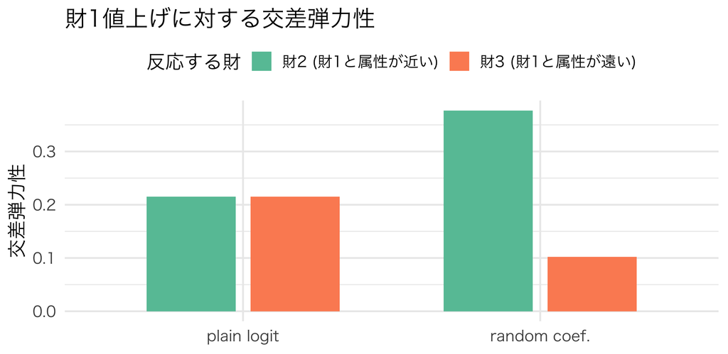

図 1

- plain logit：財2と財3が同じ高さ（IIA）
- random coefficient：財2が明確に高い

## 集計需要曲線の形も変わる

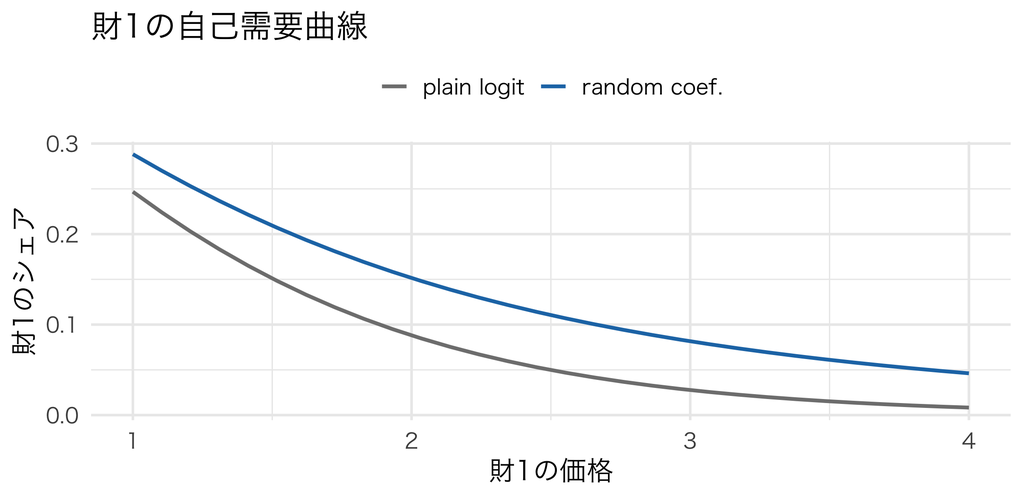

図 2

- 価格感応度がばらつくと「敏感な人がまず抜け、鈍感な人が残る」
- 集計需要の**曲がり方**が変わる → 次の識別の話につながる

# 識別：異質性はどこから分かるのか

## 識別の3つの源泉

異質性パラメータ $\sigma$ は何を見て識別されるのか：

1. **価格反応の「曲がり方」**：敏感な人が先に抜けるので、需要曲線の曲率が均質モデルとずれる
2. **市場間の選択集合・属性分布の変動**：外生、またはIVで取り出せる変動なら識別に効く
3. **micro moments（個票・アンケート）**：次のスライド

集計シェアでも、十分なsupportを持つ**関連した外生変動**と妥当な除外制約／IVがあれば、モデルの仮定のもとで $\sigma$ を識別できる。micro momentsはそこに別の制約を加える。

## micro moments：個票が識別を救う

集計シェアに、個票由来のモーメントを足す：

- 「この製品の**購入者の平均所得**はいくらか」→ $\alpha_i$ と所得の相関が直接見える
- 「購入者の **2nd choice**（第一希望がなければ何を買ったか）」→ 代替パターンそのものが観測される

2nd choice は「誰と誰が競合か」を直接制約し、対応する異質性パラメータの識別を強めうる。どのmomentがどの係数に効くかの対応づけが必要。

## 実証研究：micro moments の威力と識別条件

**Petrin (2002)**：ミニバン導入の便益

- 自動車の集計データ + 「どんな世帯が買ったか」（家族人数など）を micro moment に
- 1984–88年累計：消費者便益 **28.05億ドル**、生産者利潤込み総厚生 **29.10億ドル**（年額ではない）

**Berry and Haile (2024)**：識別理論が明示する条件

- micro dataでも、選択構造・除外変数・support・completeness等の条件のもとで識別
- 「個票とIVさえあれば自動的に識別」でも、logit/正規仮定の正当化でもない

# 推定＝ミニBLP

## ミニBLP の三層構造

$\sigma$ をシェアデータから GMM で推定する。BLP (1995) の構造だけを取り出す：

- **内側（inner loop）**：$\sigma$ を固定 → シミュレーションシェアが観測シェアに一致する $\delta$ を**縮小写像**で解く
- **中間（linear step）**：$\hat\delta(\sigma)$ を **IV回帰**（第3回の2SLS）にかけ、残差 $\hat\xi$ を得る
- **外側（outer loop）**：$\hat\xi$ が操作変数と無相関になるよう $\sigma$ を選ぶ（**GMM**）

一度手で回せば、実務ツール pyblp が中で何をしているか分かるようになる。

## DGP：観測データを作る

設定（講義ノートの軽量版。シミュレーションドロー数を絞っても結果の質は同じ）：

- $J = 3$ 財 + outside、$T = 60$ 市場、シミュレーション個人 $ns = 100$
- 真値：$\bar\alpha = 0.5$、$\sigma = 0.8$（これを回収するのがゴール）
- 価格は「限界費用 + $\xi$ に反応するマークアップ」で生成 → **内生**
- コストシフター $w$ が操作変数の種

真のDGPでは中心値を $E[\alpha_i]$ に置くので価格係数は純粋な対数正規。候補$\sigma$ごとのIVでは中心値を自由に推定するため、探索中は「推定中心値＋中心化した対数正規偏差」というshifted familyになる。純粋な対数正規を全候補で保つなら、$\bar\alpha,\sigma$をともに外側で推定する。

## 価格は内生になっている

| 財 | corr(price, xi) |
| --- | --- |
| 財1 | 0.104 |
| 財2 | 0.138 |
| 財3 | -0.073 |

## 内側：縮小写像で平均効用を解く

$\sigma$ を固定したとき、シミュレーションシェア＝観測シェアとなる $\delta$ を反復で解く：

$$\delta_{jt}^{\mathrm{new}} = \delta_{jt} + \ln s_{jt}^{\mathrm{obs}} - \ln s_{jt}(\delta, \sigma)$$

- 「予測シェアが観測より小さければ $\delta$ を上げる」という直感的な更新
- これが**縮小写像**：初期値によらず一意の $\delta$ に収束（BLP 1995 が証明）
- 初期値は plain logit の **Berry反転** $\ln s_{jt}^{\mathrm{obs}} - \ln s_{0t}^{\mathrm{obs}}$ から

## 縮小写像のコード

```r
solve_delta <- function(sigma, abar, S_obs, S0_obs, price, nu,
                        tol = 1e-10, maxit = 500, trace_t = NULL) {
  delta <- log(S_obs) - log(S0_obs)    # 初期値 = plain logit の Berry 反転
  trace <- NULL
  for (t in 1:nrow(S_obs)) {
    d <- delta[t, ]; errs <- numeric(0)
    for (it in 1:maxit) {
      s_pred <- shares_from_delta(d, price[t, ], abar, sigma, nu)
      d_new  <- d + log(S_obs[t, ]) - log(s_pred)   # 縮小写像の更新
      err <- max(abs(d_new - d)); errs <- c(errs, err); d <- d_new
      if (err < tol) break
    }
    delta[t, ] <- d
    if (!is.null(trace_t) && t == trace_t) trace <- errs
  }
  list(delta = delta, trace = trace)
}
```

## 収束の確認：幾何収束

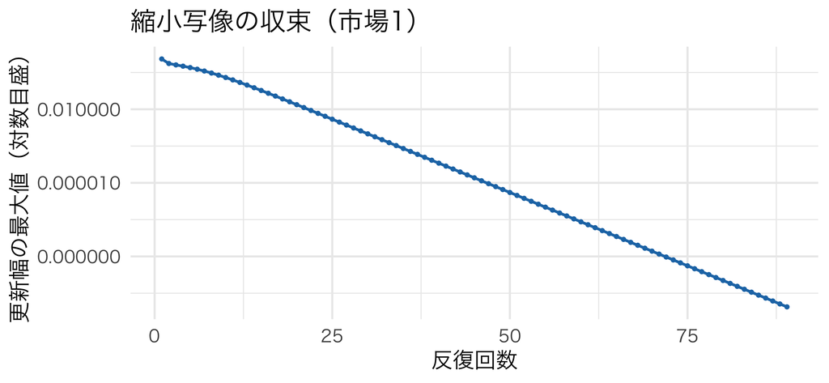

図 3

- 対数目盛でほぼ直線に誤差が落ちる＝**幾何収束**。縮小写像の指紋
- 真の $\sigma$ で解くと、シェアも $\delta$ も機械精度で再現できた（最大誤差 5.9e-10）

## 中間：IV 回帰で需要ショックを取り出す

$\hat\delta_{jt}(\sigma)$ は線形式に従う（第3回の Berry 反転後の回帰式と同じ形）：

$$\delta_{jt} = \beta_0 + \beta_x x_{jt} - \alpha_0 p_{jt} + \xi_{jt}$$

- 価格が内生なので **2SLS/GMM**。$Z$：定数、$x$、コストシフター$w$、他製品の属性和・コスト和
- 標準的BLP IVは企業IDで「同一企業の他製品」と「他企業の製品」を分ける。ここは簡略版
- 残差として $\hat\xi_{jt}$ が手に入る

## 並べ方に注意（よくあるバグ第1位）

`solve_delta` は $\delta$ を「市場 × 財」の行列で返す。IV回帰ではこれを1本のベクトルに潰すが、その順序を説明変数側と**厳密に一致させる**こと。ここがズレると $\delta$ と $x$・$p$ の対応が壊れ、推定値が無意味になる。エラーは出ないのに結果だけ狂う、最悪のタイプのバグ。

- 今回は「市場 $t$ を固定して財 $j$ を回す」順（行列の転置を `as.vector`）で統一
- 自作するときは、小さい例（2市場2財）で**目視確認**してから本番へ

## 外側：GMM 目的関数の谷

$\sigma$ をグリッドで動かし、目的関数を計算する：

$$Q(\sigma) = \hat{\xi}' Z W Z' \hat{\xi}$$

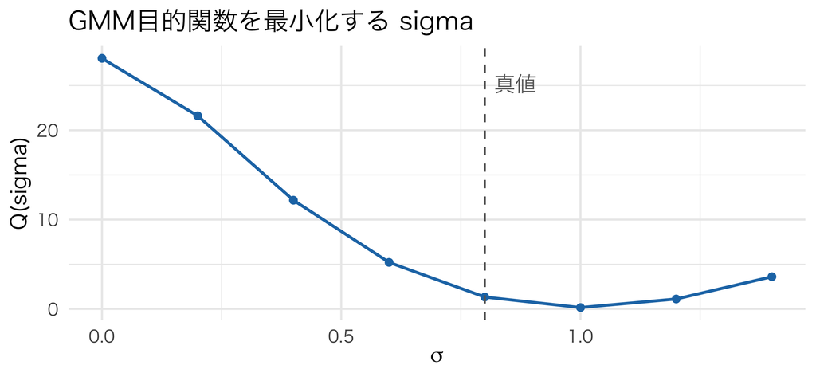

図 4

- 真値 $\sigma = 0.8$ の近くで谷 —— **異質性パラメータを回収できた**

| パラメータ | 推定値 | 真値 |
| --- | --- | --- |
| 定数 (beta_0) | 4.906 | 4.00 |
| 属性 (beta_x) | 1.632 | 1.50 |
| 価格 (-alpha_0) | -2.982 | -2.27 |

## ここが核心：ミニBLP の三層

- **内側**：$\sigma$ を固定 → 縮小写像で $\delta$ を解く（シェアを完全一致させる）
- **中間**：$\hat\delta$ を IV回帰 → 価格の内生性を除去して $\hat\xi$ を得る
- **外側**：$\hat\xi$ が操作変数と無相関になるよう $\sigma$ を選ぶ（GMM）

実務では pyblp がこれを高速・安定にやる。だが中身はこの三層。一度手で回した人は、pyblp のログを読んで「内側が収束していない」「操作変数が弱い」と**診断できる**。

## 実証研究：Berry, Levinsohn and Pakes (1995)

- **問い**：新車のシェア・価格・スペックの**集計データだけ**から、需要と各車種のマークアップを推定できるか
- **データ**：米国自動車市場 1971–1990年。個票なし
- **方法**：今日のミニBLPの完全版（random coefficient + 縮小写像 + GMM + BLP型IV）
- **発見**：コストデータを一切見ずに限界費用・マークアップを復元。マークアップ率は多くの車種で**2〜3割**

「シェアと価格しかないのに、見えない限界費用まで復元できる」——この衝撃が実証IOの出発点。

# 合併分析：供給側を入れる

## 供給側を入れると何ができるか

需要は推定できた。ここに**企業の価格設定行動**（Bertrand競争）を足すと：

1. 観測された価格・シェアから**限界費用を逆算**できる（コストデータ不要）
2. 「2社が合併したら価格がどれだけ上がるか」を**反実仮想**として計算できる

これが **merger analysis**。公正取引委員会や欧米当局の合併審査で実際に使われる。

## Bertrand-Nash の一階条件

各企業は自社製品の利潤を最大化するよう価格を選ぶ。1製品1企業なら、財 $j$ の FOC は

$$s_j + (p_j - mc_j) \frac{\partial s_j}{\partial p_j} = 0$$

- 第1項：値上げすると今のシェア分だけ利ざやが増える
- 第2項：値上げすると客が逃げて数量が減る
- このバランスで価格が決まる。需要の微分は**推定済み**（モンテカルロで計算できる）

## 多製品企業と所有行列

所有行列 $\Omega$（財 $j$ と $k$ が同じ企業なら1）を使うと、FOC は全財まとめて書ける：

$$s-\Delta(p-mc)=0,\qquad
\Delta_{jk}=-\Omega_{jk}\frac{\partial s_k}{\partial p_j}
\quad\Longleftrightarrow\quad
p=mc+\Delta^{-1}s$$

- 第2項 $\Delta^{-1} s$ が**マークアップ**
- 価格・シェア・需要の微分が分かれば → 逆に解いて **$mc$ を復元**できる
- **合併＝ $\Omega$ の該当ブロックを 0 から 1 に書き換える**だけの操作

均衡条件が「見えないコスト」を教えてくれる。そして合併の分析は所有行列の書き換えに帰着する。

## 均衡を解くコード

```r
solve_equilibrium <- function(mc, groups, p_init, tol = 1e-10, maxit = 1000) {
  p <- p_init
  for (it in 1:maxit) {
    mp <- markup_pieces(p, groups)      # Delta(p) と s(p) を計算
    p_new <- mc + solve(mp$Delta, mp$s) # p = mc + Delta^{-1} s の固定点反復
    err <- max(abs(p_new - p))
    p <- p_new
    if (err < tol) return(list(p = p, iters = it, ok = TRUE))
  }
  list(p = p, iters = maxit, ok = FALSE)
}
```

- FOC を「価格 = コスト + マークアップ」の**固定点反復**として解く
- 4財市場。推定済みの $\bar\alpha = 0.5$、$\sigma = 0.8$ をそのまま使う

## 答え合わせ：限界費用の逆算

合併前の均衡価格 $p_0$ とシェアから、FOC を逆に解いて $mc$ を復元する：

| 財 | 合併前価格 | 逆算した限界費用 | 真の限界費用 |
| --- | --- | --- | --- |
| 財1 | 1.989 | 1.0 | 1.0 |
| 財2 | 2.011 | 1.1 | 1.1 |
| 財3 | 2.177 | 1.2 | 1.2 |
| 財4 | 1.817 | 0.9 | 0.9 |

- 限界費用がぴたりと復元された。コストデータは一切使っていない

## 財1・財2が合併したら

所有行列を書き換えて（財1・財2を同一企業に）、新しい均衡を解く：

| 財 | 合併 | 合併前価格 | 合併後価格 | 変化率(%) |
| --- | --- | --- | --- | --- |
| 財1 | 当事者 | 1.989 | 2.176 | 9.43 |
| 財2 | 当事者 | 2.011 | 2.323 | 15.52 |
| 財3 |  | 2.177 | 2.193 | 0.74 |
| 財4 |  | 1.817 | 1.841 | 1.35 |

- 当事者（財1・財2）の価格が大きく上がり、非当事者はわずかに上がる
- 合併後は「財1を値上げしても、逃げた客の一部を自社の財2が受け止める」→ **値上げのブレーキが外れる**。これが**単独効果（unilateral effect）**

## 合併後の価格上昇率

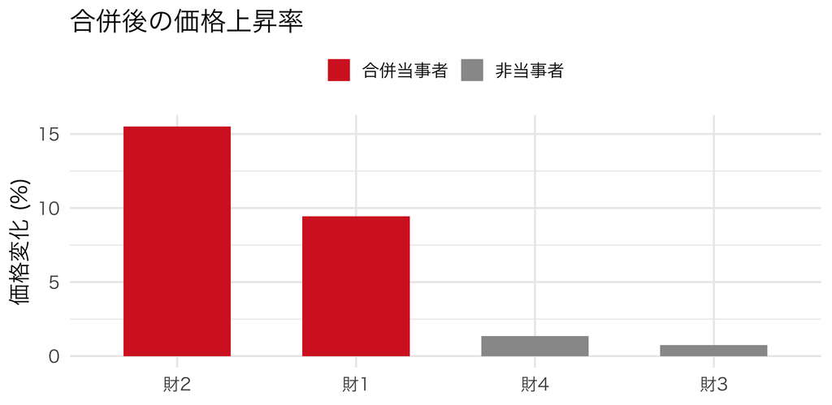

図 5

- この図が、合併審査で当局・企業双方が計算して見せ合う「本丸」の1つ

## diversion ratio と UPP

合併審査で使う簡便指標。**diversion ratio**：財 $j$ の値上げで逃げた客のうち財 $k$ へ流れる割合

$$D_{j \to k} = -\frac{\partial s_k / \partial p_j}{\partial s_j / \partial p_j}$$

これが大きいほど2財は近い代替財で、合併の弊害が大きい。**UPP**（値上げ圧力の簡便指標、効率化なし版）は $\mathrm{UPP}_1 = D_{1 \to 2}(p_2 - mc_2)$。

| 指標 | 値 |
| --- | --- |
| diversion D(1 to 2) | 0.174 |
| diversion D(2 to 1) | 0.246 |
| UPP(財1, 効率化なし) | 0.158 |

## 消費者余剰の変化

各消費者の期待効用は logsum（inclusive value）。価格の単位に直すため $1/\alpha_i$ で割って平均：

$$CS = \frac{1}{ns} \sum_{r=1}^{ns} \frac{1}{\alpha_r} \ln\left(1 + \sum_{j=1}^{J} \exp(v_{rj})\right)$$

| 時点 | 消費者余剰（1人あたり） |
| --- | --- |
| 合併前 | 1.7946 |
| 合併後 | 1.7218 |
| 変化 | -0.0728 |

- 値上げの分、消費者が損をする。これが審査で問題視される「消費者への害」

## 実証研究：合併の予測と事後検証

**Nevo (2001)**：朝食シリアルの高マージンは共謀か

- random coefficient logit + Bertrand でマークアップを計算。マージン**4〜5割**は共謀なしでも製品差別化とブランド力で説明できた
- ブランド固定効果だけでなく、他都市価格（Hausman型IV）や流通費用proxy等で価格内生性に対処

**Miller and Weinberg (2017)**：MillerCoors 合弁の事後検証

- 合弁前データで需要・供給を推定 → 単独 Nash の予測と実際の価格を比較
- 実際の値上げは単独効果の予測を**上回った** → 協調的値上げの証拠と解釈

# まとめ

## ここが核心

- 異質性を入れる＝**係数を消費者ごとに変える**（$\beta_i = \beta + \Sigma^{1/2} \nu_i$、価格係数は対数正規で正に固定）
- 個人条件付きではただの logit。積分が閉じない → **モンテカルロ積分**
- 属性に結びついた異質性で**集計IIAが破れ**、このDGPでは「属性の近い財どうしがよく代替する」が出る
- 推定は**ミニBLPの三層**：縮小写像 → IV回帰 → GMM。GMMの谷が真値 $\sigma = 0.8$ の近くに現れた
- 識別には **micro moments**（購入者属性・2nd choice）が効く
- 供給側を足すと $p = mc + \Delta^{-1} s$：**限界費用の復元**と**合併後の価格上昇**の計算ができる

## 宿題

- **pyblp のドキュメントを眺める**：チュートリアルの「problem」「integration」「optimization」が今日の三層のどこに対応するか対応づける（コードは動かさなくてよい）
- 交差弾力性のコードで `x_char` を `c(1.0, -0.9, -0.8)`（財1と財2を遠く）に変えて、財1と財2の交差弾力性がどう変わるか観察する
- 合併分析で `groups_post` を `c(1, 1, 1, 4)`（3社合併）に変えて、価格上昇率の変化を見る
- **coding課題は `assignment4.qmd`**：DGP自作 → $\sigma$ のグリッドGMM → 合併分析まで、今日のすべてを自分の手で通す

## 次回予告：ゲスト講義（合併審査の実務）

- 第5回は**公正取引委員会**の方をお招きし、**企業結合審査の実務**を伺う
- 今日計算した diversion ratio・UPP・単独効果・消費者余剰が、現実の審査でどう使われ、どこが争点になるのか
- 経済分析を提出する側（企業・コンサル）と審査する側の攻防を、**道具を握った状態で**聞いてほしい
- 第6回は、母集団の異質性と個人の購買履歴を組み合わせた選択予測へ
- 第7回で、選好を測る選択課題を設計する**コンジョイント分析**へ

**Reading**：上武ほか『実証ビジネス・エコノミクス』第4章、Nevo (2000)、Berry, Levinsohn and Pakes (1995)